# STAT 385 Fall 2019 - Week 11 Instructor Notes: parallel computing

Daniel Eck

## Last Time / Updates

- visualizations with ggplot
- load in big data (demonstration below)

#### A demonstration of how to load in Big Data

Make sure that you create a BigData directory in your STAT385 directory. Recall that you can do that using your computer’s terminal

```
mkdir ~/Desktop/STAT385/BigData
```

Clear R’s global environment of all objects (memory dump)

```r
rm(list = ls())
library(tidyverse)
```

Make the data that we are going to load in chunks.

```r
set.seed(13)
nat <- as.data.frame(matrix(rnorm(8e6),ncol=20))
dim(nat)
for (i in 1:20){
  nati <- nat[(1:20000)+20000*(i-1)  ,]
  write_csv(nati,paste("~/Desktop/STAT385/BigData/natp",i,".csv", sep=""))
  rm(nati)
}
rm(nat)
```

Importing the first part of the big data

```r
nat1 <- read_csv("~/Desktop/STAT385/BigData/natp1.csv")
dim(nat1)
colnames(nat1) <- paste("X",1:ncol(nat1), sep="")
```

Now do the data cleaning you need for one part.

```r
# only keep the rows corresponding to some question
nat1 <- filter(nat1, X1> 0.15 & X2<0.01)
nat1 <- select(nat1, X1, X2, X6)
dim(nat1)
```

Then repeat this process on all remaining parts with a loop.

```r
nat <- nat1 # initialize
for (i in 2:20){
  nat1 <- read_csv(paste("~/Desktop/STAT385/BigData/natp",i,".csv", sep=""))
  colnames(nat1) <- paste("X",1:ncol(nat1), sep="")
  nat1 <- filter(nat1, X1> 0.15 & X2<0.01)
  nat1 <- select(nat1, X1, X2, X6)
  nat <- rbind(nat,nat1)
  rm(nat1)
}
ls() # we only have the cleaned and smaller dataset and we have removed all the big data and the memory associated with those big files
```

##### Question: Can we do this with parallel programming?

The answer should be yes. See problem 2 in Homework 6. We will discuss parallel programming next time.

## Parallel Programming

Select resources on parallel computing follow from [here](https://nceas.github.io/oss-lessons/parallel-computing-in-r/parallel-computing-in-r.html). These notes require that you have installed the following R packages:

```r
library(parallel)
library(foreach)
library(doParallel)
library(palmerpenguins)
```

## Why parallelism?

A lot of the computational tasks that we have done so far run fast and fine on a single processor. That will not always the case, some computational tasks can exhaust the resources of our computers. At times, computations can be:

- cpu-bound: Take too much cpu time
- memory-bound: Take too much memory
- I/O-bound: Take too much time to read/write from disk
- network-bound: Take too much time to transfer

To help with cpu-bound computations, one can take advantage of modern processor architectures that provide multiple cores on a single processor, and thereby enable multiple computations to take place at the same time. In addition, some machines are created with multiple processors, allowing large computations to occur across the entire cluster of those computers. Plus, these machines also have large amounts of memory to avoid memory-bound computing jobs.

## Processors (CPUs) and Cores

A modern CPU (Central Processing Unit) is at the heart of every computer. While traditional computers had a single CPU, modern computers can be equipped with multiple processors, which in turn can each contain multiple cores. These processors and cores are available to perform computations. Think of each core as an independent computer that can perform computational tasks for you when it is accessed.

How many cores does your computer have available? Run the following code to find out.

```r
detectCores()
```

```
## [1] 16
```

```r
## set the number of cores to the number available minus 1
## so that your computer has memory to perform other tasks
numCores <- detectCores() - 1
```

## When to parallelize

While in theory each added processor would linearly increase the productivity of a computation, there is overhead that reduces that efficiency. For example, the code and, importantly, the data need to be copied to each additional CPU, and this takes time and bandwidth. Plus, new processes and/or threads need to be created by the operating system, which also takes time. This overhead reduces the efficiency enough that realistic performance gains are much less than theoretical, and usually do not scale linearly as a function of processing power.

See the [Embarrassingly parallel](https://en.wikipedia.org/wiki/Embarrassingly_parallel) Wikipedia page for examples of when to parallelize.

## Loops and repetitive tasks using lapply

When you have a list of repetitive tasks, you may be able to speed it up by adding more computing power. If each task is completely independent of the others, then it is a prime candidate for executing those tasks in parallel, each on its own core. We have seen some examples of parallelizable tasks in this course, the bootstrap and Monte Carlo simulation examples could be sped up with parallel computing.

We will show the benefits of parallel computing with a bootstrap example. We will first add data to the global environment outside of a cached code chunk (this makes my life easier when creating this document, why?)

```r
penguins <- penguins[complete.cases(penguins), ]
x <- penguins[which(penguins$species != "Adelie"), c(1,5)]
```

We now perform a bootstrap that takes too long.

```r
set.seed(13)
x <- data.frame(x)
n <- nrow(x)
trials <- 10000
res <- data.frame()
system.time({
  trial <- 1
  while(trial <= trials) {
    ind <- sample(1:n, replace=TRUE)
    result1 <- lm(x[ind, 2] ~ x[ind, 1])
    r <- coefficients(result1)
    res <- rbind(res, r)
    trial <- trial + 1
  }
})
```

```
##    user  system elapsed
##  10.510   0.305  10.823
```

The issue with this loop is that we execute each trial sequentially, which means that only one of our cores on this machine are in use. In order to exploit parallelism, we need to be able to dispatch our tasks as functions, with one task going to each processor. Here’s the same code rewritten to use lapply(), which applies a function to each of the members of a list (in this case the trials we want to run). We first write the `boot_fx` function.

```r
boot_fx <- function(trial) {
  ind <- sample(1:n, replace=TRUE)
  result1 <- lm(x[ind, 2] ~ x[ind, 1])
  coefficients(result1)
}
```

We now use `lapply` to perform the bootstrap. Again, it is too slow.

```r
set.seed(13)
trials <- seq(1, 10000)
system.time({
  results <- do.call(rbind, lapply(trials, boot_fx))
})
```

```
##    user  system elapsed
##   8.785   0.027   8.821
```

## Parallelize using: mclapply

**Note** The mclapply() function (and related mc* functions) use the fork clustering mechanism on Unix-style operating systems. Because of this, the mc* functions are generally not applicable on Windows operating system. We will introduce parallel computing using mclapply because of its similar syntax to the apply family of functions that we have seen before. The bulk of these lecture notes will use parallel implementations that are applicable for users of all operating systems.

The parallel library can be used to send tasks (encoded as function calls) to each of the processing cores on your machine in parallel. This is done by using the parallel::mclapply function, which is analogous to lapply, but distributes the tasks to multiple processors.

```r
set.seed(13)
system.time({
  results <- do.call(rbind, mclapply(trials, boot_fx, mc.cores = numCores))
})
```

```
##    user  system elapsed
##   4.736   0.519   1.426
```

## Parallelize using: parLapply

The same task can be performed using `parLapply`. This time we will create a cluster, export necessary quantities to the cluster, run our task in parallel, and then close the cluster.

```r
system.time({
  ## make cluster
  cl <- makePSOCKcluster(numCores)

  ## make created cluster the default cluster
  setDefaultCluster(cl)

  ## move necessary objects in the global environment to the
  ## environment of the cluster
  clusterExport(NULL, c('boot_fx','x','n'))

  ## perform parallel computing task
  results <- do.call(rbind, parLapply(NULL, trials, function(trial) boot_fx(trial)))
})
```

```
##    user  system elapsed
##   0.029   0.010   1.852
```

```r
system.time({
  results <- do.call(rbind, parLapply(NULL, trials, function(trial) boot_fx(trial)))
})
```

```
##    user  system elapsed
##   0.017   0.002   1.567
```

```r
# Make sure to close the cluster when you are done.
stopCluster(cl)
```

Note that R generates plenty of “closing unused connection” warning messages. These are not fatal errors, basically R automatically closes down the previous cluster call automatically and then performs the new parallel task on the existing cluster.

See [here](https://bookdown.org/rdpeng/rprogdatascience/parallel-computation.html) for more detail on coding with the `parallel` R package.

### Reproducibility with parLapply

All of the above `parLapply` calls are not reproducible, if we remove our cache directory and rerun the code then the results will be different. We can circumvent this problem by adding a random seed to out declared cluster using the `clusterSetupRNGstream` function.

```r
library(snow)
library(rlecuyer)
cl <- makePSOCKcluster(numCores)
clusterExport(cl, c('boot_fx','x','n'))
## add a random seed to a cluster
clusterSetupRNGstream(cl,seed=13)
setDefaultCluster(cl)
results <- do.call(rbind, parLapply(cl, trials, function(trial) boot_fx(trial)))
stopCluster(cl)
```

We see that creating the above cluster in the exact same manner leads to a reproducible parallel implementation.

```r
cl <- makePSOCKcluster(numCores)
clusterExport(cl, c('boot_fx','x','n'))
## add a random seed to a cluster
clusterSetupRNGstream(cl,seed=13)
setDefaultCluster(cl)
results2 <- do.call(rbind, parLapply(cl, trials, function(trial) boot_fx(trial)))
stopCluster(cl)
all.equal(results, results2)
```

```
## [1] TRUE
```

### Reproducibility with mclapply (proceed with caution)

We are going to skip this since: 1) it is not relevant for all users; 2) it is more difficult.

We need to change the random number generator in R for our call to `mclapply` to be reproducible. This is because base R does not forward the user set seed to each processor.

```r
RNGkind("L'Ecuyer-CMRG")
```

The idea of L’Ecuyer et al (2002) is to use a separate stream for each of the parallel computations (which ensures that the random numbers generated never get into to sync).

```r
set.seed(13)
system.time({
  results <- do.call(rbind, mclapply(trials, boot_fx, mc.cores = numCores))
})
```

```
##    user  system elapsed
##  22.257   2.110   1.713
```

Note that an additional call to `mclapply` does not alter the state of the random generator of the master process (ie the random number generator in your global environment).

```r
system.time({
  results2 <- do.call(rbind, mclapply(trials, boot_fx, mc.cores = numCores))
})
```

```
##    user  system elapsed
##  22.293   2.090   1.773
```

```r
all.equal(results, results2)
```

```
## [1] TRUE
```

For some purposes it is fine that a call to `mclapply` does not alter the random seed in the master process (your global environment). However, it is problemmatic for Monte Carlo simulation studies. We can get around it by skipping over random number streams.

```r
skip.streams <- function(n) {
  x <- .Random.seed
  for (i in seq_len(n))
    x <- nextRNGStream(x)
  assign('.Random.seed', x, pos=.GlobalEnv)
}
```

Let’s try it.

```r
skip.streams(3)
results3 <- do.call(rbind, mclapply(trials, boot_fx, mc.cores = numCores))
skip.streams(3)
results4 <- do.call(rbind, mclapply(trials, boot_fx, mc.cores = numCores))
head(all.equal(results2, results3))
```

```
## [1] "Mean relative difference: 0.009893455"
```

```r
head(all.equal(results3, results4))
```

```
## [1] "Mean relative difference: 0.009920344"
```

It worked. We can return to base R’s default random number generator when we are finished.

```r
RNGkind("default")
```

## Parallelize using: foreach and doParallel

According to some, the `parallel` library is a more advanced and user-controlled way to perform parallel programming. The `doParallel` package could be considered simpler with fewer user-controls, but effective. Because the easy implementations of parallel programming with the `parallel` package are dependent on the `multicore` package does not allow Windows systems to run on multiple cores, we will focus on the `doParallel` package.

Below is an example of bootstrapping directly borrowed from S. Weston and R. Calaway’s **[Getting Started with doParallel and foreach](https://cran.r-project.org/web/packages/doParallel/vignettes/gettingstartedParallel.pdf)**. First, a quick example:

```r
library(doParallel)
numCores <- getDoParWorkers()
cl <- makeCluster(numCores)
registerDoParallel(cl)
foreach(i=1:3) %dopar% sqrt(i)
```

```
## [[1]]
## [1] 1
##
## [[2]]
## [1] 1.414214
##
## [[3]]
## [1] 1.732051
```

```r
registerDoParallel(cores=2) #multicore
foreach(i=1:3) %dopar% sqrt(i)
```

```
## [[1]]
## [1] 1
##
## [[2]]
## [1] 1.414214
##
## [[3]]
## [1] 1.732051
```

```r
stopCluster(cl)
```

We now continue with the bootstrap example using the `doParallel` package.

```r
#makecluster i.e. set the number of workers for parallel programming
cl <- makeCluster(numCores)
registerDoParallel(cores = 10)
getDoParWorkers() # to see how many workers foreach is going to use
```

```
## [1] 10
```

```r
x <- as.data.frame(penguins[which(penguins$species != "Adelie"), c(1,5)])
trials <- 10000

ptime <- system.time({
  r <- foreach(icount(trials),.combine=rbind) %dopar% {
  ind <- sample(1:n, replace=TRUE)
  result1 <- lm(x[ind,2] ~ x[ind,1])
  coefficients(result1)
  }
})[3]
ptime #parallel processing time
```

```
## elapsed
##    3.25
```

```r
stopCluster(cl) #stopcluster. run this when done with parallel programming to free up computing power
```

Below is its sequential counterpart (code from S. Weston and R. Calaway).

```r
stime <- system.time({
  r <- foreach(icount(trials),.combine=cbind) %do% { #do not doPar
  ind <- sample(1:n, replace=TRUE)
  result1 <- lm(x[ind,2] ~ x[ind,1])
  coefficients(result1)
  }
})[3]
stime #sequential processing time
```

```
## elapsed
##  10.945
```

### Loading in datasets using foreach

```r
library(tidyverse)
nat <- NULL # initialize
system.time({
for (i in 1:20){
  nat1 <- read_csv(paste("~/Desktop/STAT385/BigData/natp",i,".csv", sep=""))
  colnames(nat1) <- paste("X",1:ncol(nat1), sep="")
  nat1 <- filter(nat1, X1> 0.15 & X2<0.01)
  nat1 <- select(nat1, X1, X2, X6)
  if(i == 1) nat <- nat1
  else nat <- rbind(nat,nat1)
  rm(nat1)
}})
```

```
##    user  system elapsed
##   3.387   0.236   4.222
```

```r
ls() # we only have the cleaned and smaller dataset and we have removed all the big data and the memory associated with those big files
```

```
##  [1] "boot_fx"      "cl"           "i"            "ind"          "n"
##  [6] "nat"          "numCores"     "penguins"     "ptime"        "r"
## [11] "res"          "result1"      "results"      "results2"     "results3"
## [16] "results4"     "skip.streams" "stime"        "trial"        "trials"
## [21] "x"
```

We will now clear the global environment and load in the dataset using `foreach` functionality.

```r
rm(list = ls()) # clear global environment
numCores <- detectCores() - 1
registerDoParallel(cores = numCores) # use multicore, you may want to
                                     # change the number of cores to 2 or 4.
ptime <- system.time({
  nat <- foreach(i=1:20,.combine=rbind) %dopar% {
    library(tidyverse)
    nat1 <- read_csv(paste("~/Desktop/STAT385/BigData/natp",i,".csv", sep=""))
    colnames(nat1) <- paste("X",1:ncol(nat1), sep="")
    nat1 <- filter(nat1, X1> 0.15 & X2<0.01)
    nat1 <- select(nat1, X1, X2, X6)
    #if(i == 1) nat <- nat1
    #else nat <- rbind(nat,nat1)
    #rm(nat1)
    nat1
  }
})
ptime #parallel processing time
```

```
##    user  system elapsed
##   5.552   0.905   0.604
```

```r
ls() # we only have the cleaned and smaller dataset and we have removed all the big data and the memory associated with those big files
```

```
## [1] "nat"      "numCores" "ptime"
```

Why does the `library(tidyverse)` call exist inside the `foreach` loop?

### Description of foreach

`%do%` and `%dopar%` are binary operators that operate on a foreach object and an R expression. **The expression, ex, is evaluated multiple times in an environment that is created by the foreach object, and that environment is modified for each evaluation as specified by the foreach object**. %do% evaluates the expression sequentially, while %dopar% evalutes it in parallel. The results of evaluating ex are returned as a list by default, but this can be modified by means of the .combine argument.

For more resources on loading in big datasets, see [here](https://rpubs.com/msundar/large_data_analysis).

Another good resource on parallel computing can be seen [here](http://gforge.se/2015/02/how-to-go-parallel-in-r-basics-tips/).

### Revisiting numerical integration

We alter the `integrate_Darboux_monotone` function from the Week 7 Notes to create the `integrate_Riemann` function below. This new function does not fuss about monotonicity and just computes the area of Riemannian rectangles by multiplying the length of the domain of each element of the partition by the value of the function when evaluated at the largest element of each element of the partition. See for yourself.

```r
integrate_Riemann <- function(a, b, n, FUN){

  # pick uniform partition of the domain
  x <- seq(from = a, to = b, length = n)

  # compute and sum Riemann rectangles with respect to our
  # uniform partition
  Rect <- sum(sapply(x[-1], FUN)) * (x[2] - x[1])
  Rect
}
```

We now calculate the integral of a relatively complicated function over a large range of integration while maintaining fine precision.

```r
## estimate integral of complicated function from 0 to 100
n = 5e6; a = 0; b = 100
system.time({
Area <- integrate_Riemann(a = a, b = b, n = n,
  FUN = function(x) x - 10*log(x)*ifelse(x > 0.2, 1, 0))
})
```

```
##    user  system elapsed
##  15.897   0.162  16.066
```

```r
Area
```

```
## [1] 1389.612
```

Too slow… Why? Can the speed be improved with parallelization? How?

```r
## estimate integral of complicated function from 0 to 100
n = 5e6; a = 0; b = 100
numCores = 10
registerDoParallel(cores = numCores)
ptime <- system.time({
  Area_mat <- foreach(i=1:numCores,.combine=rbind,
                      .export=c("integrate_Riemann")) %dopar% {
    integrate_Riemann(a = b*((i-1)/10), b = b*(i/10), n = n/numCores,
      FUN = function(x) x - 10*log(x)*ifelse(x > 0.2, 1, 0))
  }
  Area2 <- as.numeric(colSums(Area_mat))
})
ptime #parallel processing time
```

```
##    user  system elapsed
##   0.015   0.015   1.830
```

```r
Area2
```

```
## [1] 1389.612
```

Try again with same number of cores but more iterations.

```r
## estimate integral of complicated function from 0 to 100
n = 5e6; a = 0; b = 100
numCores = 10
niter = 100
registerDoParallel(cores = numCores)
ptime <- system.time({
  Area_mat <- foreach(i=1:niter,.combine=rbind,
                      .export=c("integrate_Riemann")) %dopar% {
    integrate_Riemann(a = b*((i-1)/niter), b = b*(i/niter),
                      n = n/niter,
      FUN = function(x) x - 10*log(x)*ifelse(x > 0.2, 1, 0))
  }
  Area3 <- as.numeric(colSums(Area_mat))
})
ptime #parallel processing time
```

```
##    user  system elapsed
##  11.538   1.976   1.743
```

```r
Area3
```

```
## [1] 1389.612
```

### Line search to compute highest density region

**Important:** This exercise will be very helpful for homework 6.

We will use parallelization to compute a minimal length highest density confidence region for linear regression. We will restrict attention to the normal errors (much easier). The model is $y = \beta_0 + \beta_1x + e$, we will set $\beta_0 = 1$ and $\beta_1 = 2$, and we will suppose that $x \in [0,1]$. Furthermore $e \sim N(0, \sigma)$ where we specify that $\sigma = 1$.

```r
lwr = 0; upr = 1
b0 = 1; b1 = 2; sigma = 1
mu_x <- function(x) b0 + b1 * x
```

We want to visualize the minimal length highest density confidence region for the regression model with these specifications. This is not a statistical inference problem, it is an optimization problem. We first need a function that calls pnorm at each $(x,y)$ point under consideration.

```r
cum_prob <- function(x, y){
  pnorm(y, mean = mu_x(x), sd = sigma)
}
```

We will use some distributional theory to guide us, mainly that the Normal distribution is symmetric and bell-shaped. These properties combine to imply that `cum_prob(x, mu_x(x)) = 0.5` for all `x`, see some examples

```r
cum_prob(0.1, mu_x(0.1))
```

```
## [1] 0.5
```

```r
cum_prob(0.5, mu_x(0.5))
```

```
## [1] 0.5
```

```r
cum_prob(0.9, mu_x(0.9))
```

```
## [1] 0.5
```

We form the upper end of the confidence region at a particular `x` by starting `y` at `mu_x(x)` and then increasing `y` until `cum_prob(y, mu_x(0.1))` exceeds 0.975. This is a line search.

```r
xcand = 0.5
yupr = cum_prob(0.5, mu_x(0.5))
prec = 0.001
while(cum_prob(0.5, yupr) < 0.975){
  yupr <- yupr + prec
}
yupr
```

```
## [1] 3.96
```

Do the analogous thing for the lower value.

```r
xcand = 0.5
ylwr = cum_prob(0.5, mu_x(0.5))
prec = 0.001
while(cum_prob(0.5, ylwr) > 0.025){
  ylwr <- ylwr - prec
}
ylwr
```

```
## [1] 0.04
```

Let’s collect our line searches into a single function.

```r
min_region <- function(x, prec = 0.001){
  ylwr <- yupr <- mu_x(x)
  while(cum_prob(x, yupr) < 0.975){
    yupr <- yupr + prec
  }
  while(cum_prob(x, ylwr) > 0.025){
    ylwr <- ylwr - prec
  }
  c(ylwr,yupr)
}
```

Now compute the minimal length highest density region at 1000 evenly spaced values of $x \in [0,1]$.

```r
x <- seq(0, 1, length = 1000)
ptime <- system.time({
  reg <- do.call(rbind, lapply(x, min_region))
})
ptime
```

```
##    user  system elapsed
##   9.587   0.085   9.679
```

```r
head(reg)
```

```
##           [,1]     [,2]
## [1,] -0.960000 2.960000
## [2,] -0.957998 2.962002
## [3,] -0.955996 2.964004
## [4,] -0.953994 2.966006
## [5,] -0.951992 2.968008
## [6,] -0.949990 2.970010
```

Cool, but that was slow. We try again using `foreach`.

```r
numCores = 10
registerDoParallel(cores = numCores)
ptime <- system.time({
  reg2 <- foreach(i=1:length(x),.combine=rbind,
                      .export=c("min_region")) %dopar% {
    min_region(x[i])
  }
})
ptime #parallel processing time
```

```
##    user  system elapsed
##  15.557   2.121   1.938
```

```r
unique(reg - reg2)
```

```
##          [,1] [,2]
## result.1    0    0
```

Awesome! Let’s plot it. The plot below displays the minimal length 95% confidence region (area between the red lines). The true regression line is depicted in black.

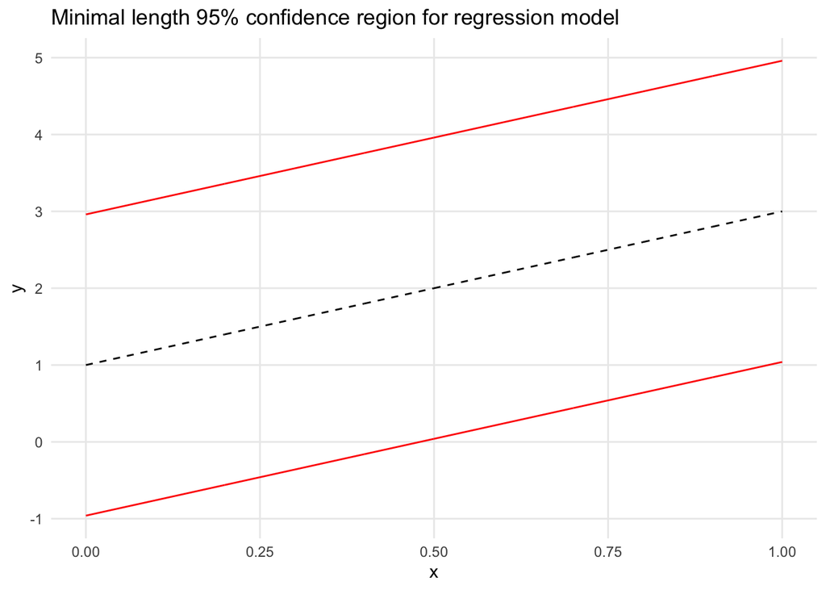

```r
region <- as.data.frame(cbind(x,reg2))
colnames(region) <- c("x", "lwr", "upr")
ggplot(data = region) +
  theme(legend.position = "none") +
  geom_line(mapping = aes(x = x, y = lwr), lty = 1, col = "red") +
  geom_line(mapping = aes(x = x, y = mu_x(x)), lty = 2) +
  geom_line(mapping = aes(x = x, y = upr), lty = 1, col = "red") +
  labs(y="y", x="x", title = "Minimal length 95% confidence region for regression model") +
  theme_minimal() +
  scale_x_continuous(minor_breaks = NULL) +
  scale_y_continuous(minor_breaks = NULL)
```

### Task to Do

1. Read through the code in both the parallel and doParallel programming chunks. Add comments that help you understand what’s happening in each line.
2. See the timetrial.html document in the stat385resources repository for an opportunity for bonus points.

### References

L’Ecuyer, P., Simard, R., Chen, E. J. and Kelton, W. D. (2002). An object-oriented random-number package with many long streams and substreams. Operations Research, 50, 1073–1075. doi: 10.1287/opre.50.6.1073.358.